# FigureYa28color

小丫画图出品

8/12/2018

微信ID: epigenomics E-mail: epigenomics@rainbow-genome.com

### 需求描述

虽然有那么多调色板：

https://www.nceas.ucsb.edu/~frazier/RSpatialGuides/colorPaletteCheatsheet.pdf

还有那么多配色方案：

https://cran.r-project.org/web/packages/ggsci/vignettes/ggsci.html

当我为paper结果图选颜色时，还是会对自己的审美不自信。

那就模仿你（或者你老板）心仪的paper的配色方案吧！

### 应用场景

本套代码要做的就是从你心仪的paper里提取它的配色方案。

如果你需要大量的颜色，那就选一篇颜色丰富的paper。

### 颜色提取

用到Y叔推荐的`rPlotter`包https://mp.weixin.qq.com/s/ZrS8IQOMSwx9R3006HYryA，先安装它

```r
install.packages(c("ggplot2", "stringr", "reshape2", "dichromat"))

source("http://bioconductor.org/biocLite.R")
biocLite("EBImage")

library(devtools)
install_github("ramnathv/rblocks")
install_github("woobe/rPlotter")
```

此处以https://www.nature.com/articles/nature22973这篇paper为例，提取正文Figure的颜色

同一篇paper里的图通常会使用同一套配色方案，这样全文看起来才协调。

因此，通常挑选其中最具代表性的1个Figure提取颜色就够了，例文的Figure 2最为典型。

#### 提取Figure 2的颜色

```r
library(rPlotter)
#其中`num_col =`参数默认值是5，此处设置为30，提取30种颜色
mycol<-extract_colours("https://media.nature.com/lw926/nature-assets/nature/journal/v547/n7663/images/nature22973-f2.jpg",num_col = 30)
mycol
```

```
##  [1] "#46534F" "#697D98" "#6C8E59" "#866460" "#898BB5" "#923B33" "#957D84"
##  [8] "#979599" "#9DB68D" "#A9A8A8" "#AE7653" "#B2A6CA" "#B5D2A0" "#BACBE1"
## [15] "#BBBCBA" "#BDB279" "#CBCBCA" "#CCE6F1" "#D0CECF" "#D1A6A8" "#D8D6D6"
## [22] "#DF9D73" "#E0DEDE" "#E3E0B1" "#E9E8E6" "#F1F1F1" "#F7E897" "#F8F9F6"
## [29] "#FCFCFC" "#FFFFFF"
```

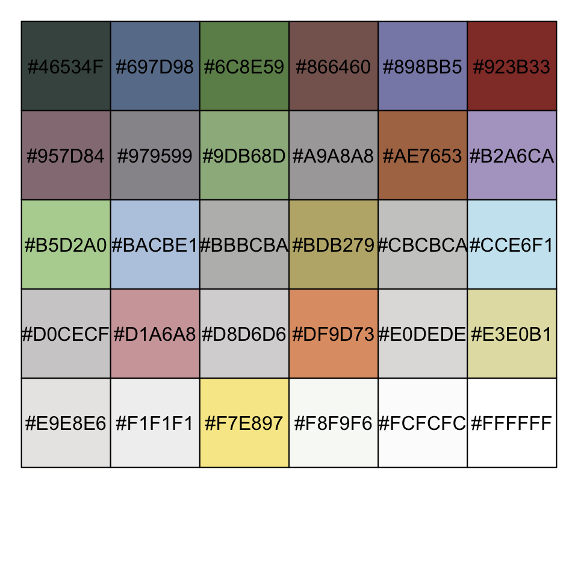

```r
#展示颜色
library("scales")
show_col(mycol)
```

```r
#保存颜色和代码到PDF文件，制作配色卡
pdf("Fig2.pdf")
show_col(mycol)
dev.off()
```

```r
#保存颜色代码到文本文件
write.table(mycol,"Fig2.txt",row.names = F,col.names = F)
```

如果你不满足于一个图的颜色，还可以一步提取全文所有图的颜色。

Paper里的Figure地址都是有规律可循的，拿到一个Figure的地址，就能推测出其他Figure的地址。

找到地址的规律，就可以用`for`循环提取所有Figure的颜色。

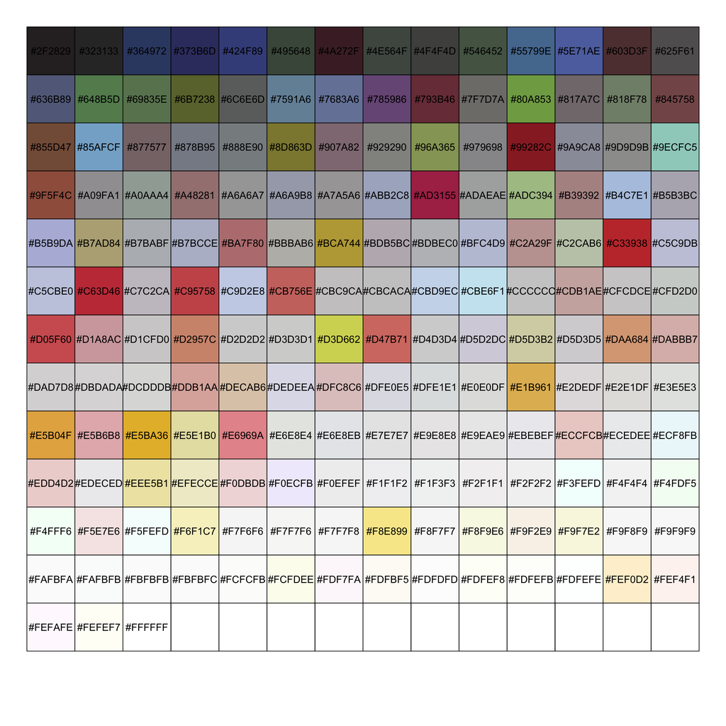

```r
#library(rPlotter)
allcol<-list()
for (i in 1:6){
  #fig<-paste0("https://media.nature.com/lw926/nature-assets/nature/journal/v547/n7663/images/nature22973-f",i,".jpg")
  #如果网速慢，或者没有在线打开的权限，就提前把图片保存在当前目录
  #从当前目录读取图片文件
  fig<-paste0("nature22973-f",i,".jpg")
  allcol<-append(allcol,extract_colours(fig, num_col = 30))
}

#去除重复出现的颜色
allcol<-base::unique(unlist(allcol))

#颜色排序
allcol<-allcol[order(allcol)]

#展示颜色
library("scales")
show_col(allcol)
```

颜色多了，用一维展示看起来乱，用三维展示

Have fun!

```r
#转换为RGB
allcol_rgb<-data.frame(t(col2rgb(allcol)))
allcol_rgb$col<-allcol

#install.packages("rgl")
library(rgl)
plot3d(allcol_rgb$red,allcol_rgb$green,allcol_rgb$blue,
       xlab = "red",ylab = "green",zlab = "blue",
       col = allcol_rgb$col,
       type = "s",
       size = 0.75,
       lit = F)

#保存颜色
write.table(allcol,"allcol.txt",row.names = F,col.names = F)
```

### 增减颜色

- 增加过渡色。为了产生同一色系，让画图效果更协调，有时会在几种颜色中间添加过渡色。

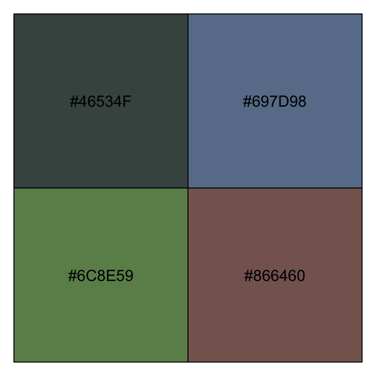

```r
#例如，想用mycol的前4个颜色：
show_col(mycol[1:4])
```

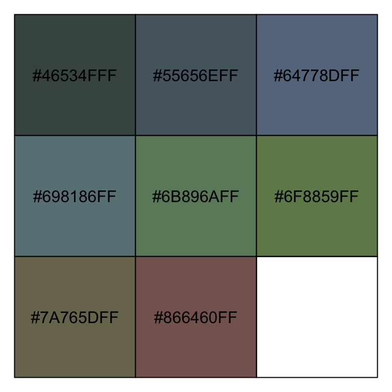

```r
#需要扩展成8种颜色
mycol_plus<-colorRampPalette(mycol[1:4],alpha=TRUE)(8)
show_col(mycol_plus)
```

```r
#保存颜色
write.table(mycol_plus,"Fig2_plus.txt",row.names = F,col.names = F)
```

- 缩减颜色。如果只想要其中一部分颜色，可以手动编辑“allcol.txt”文件，还可以用上面的方法抽取部分颜色。

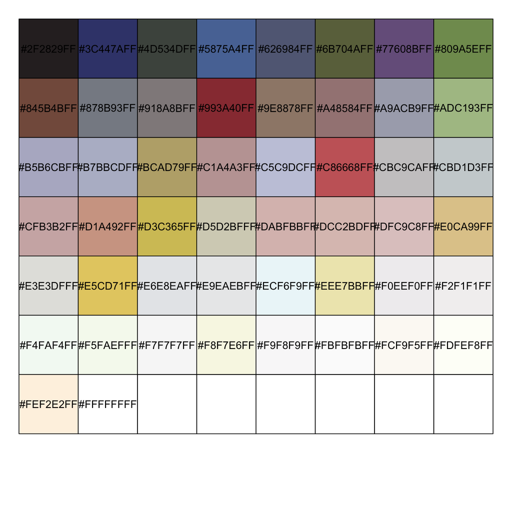

```r
#例如，allcol颜色太多，只抽取50个颜色
allcol_minus<-colorRampPalette(allcol,alpha=TRUE)(50)
show_col(allcol_minus)
```

```r
#保存颜色
write.table(allcol_minus,"allcol_minus.txt",row.names = F,col.names = F)
```

### 颜色的用法

上面获得的`mycol`就可以用到其他的画图代码中

#### 用法一

替换代码中的自定义颜色，例如`FigureYa3 genomeView`、`FigureYa24 ROC`，`FigureYa25 Sankey`，`FigureYa26 circos_R`，`FigureYa27 t-SNE`。

在画图代码中找到`mycol<-`那一行，在`FigureYa3 genomeView`里是`colpal<-`，在`FigureYa26 circos_R`里是`bgcol<-`。用下面这三行替换它：

```r
mycol<-read.table("Fig2.txt")#此处使用Figure 2的颜色
mycol<-as.character(mycol$V1)
#mycol
```

#### 用法二

定义单个颜色，例如`FigureYa1 survivalCurve`、`FigureYa9 heatmap`、`FigureYa5 bubbles`

在画图代码中找到类似下面这样的语句：

```r
palette = c("red","blue")
```

```r
colours = c("#2381B3","#F0E366")
```

用你喜欢的颜色代码替换括号里的颜色代码。

#### 用法三

有几套代码的颜色写在输入文件中，修改输入文件中的颜色，例如`FigureYa8 RadarChart`、`FigureYa10 chromosome`、`FigureYa26 circos_R`。

打开输入文件，找到颜色列，用你喜欢的颜色代码替换原来的颜色，注意去掉`#`符号